# Inside Item Memory

> This notebook focuses on item memory inside the rooms.

# 1 Overview of the data

The rooms were separated into *Familiar* and *Novel* groups. Participants explored the *Familiar* group at the beginning of the experiment. In the encoding task, they visisted both *Familiar* and *Novel* groups. Their item memory (i.e., in which room they saw the item) was tested in the memory test the next day of the encoding task. **Novelty benefits** on the item memory are examined by comparing the memory performance between the *Familiar* and *Novel* groups.

Participants were also asked to rate how curious they felt about the room. The higher the rating is means they felt more curious about the room. Item memory as a function of curiosity rating was also examined for **curiosity benefits**.

Questionnaires on personal traits regarding curiosity were also administered to participants before the encoding task (i.e., PC and EC). Scores on these questionnaires might be able to predict the item memory or its relationship with curiosity rating.

In the encoding task, there were 6 objects in each room, and the participant saw the object after openning each of the six box. It is possbile that the item memory for the object to some extent depends on the order in which the object was seen. For example, it may be easier to remember where the first and last objects were seen as compared to those in the middle.

# 2 Visual inspection of the data

```r
Encoding.Recall.Freq.Grp$Type <- "Good"
Encoding.Recall.Freq.Grp[SubjectNo %in% bad.ps.less.strict]$Type <- "Bad"
Encoding.Recall.Freq.Rsp$Type <- "Good"
Encoding.Recall.Freq.Rsp[SubjectNo %in% bad.ps.less.strict]$Type <- "Bad"
```

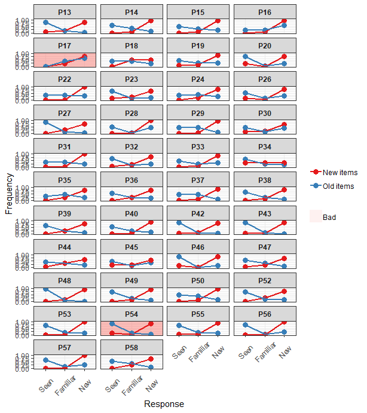

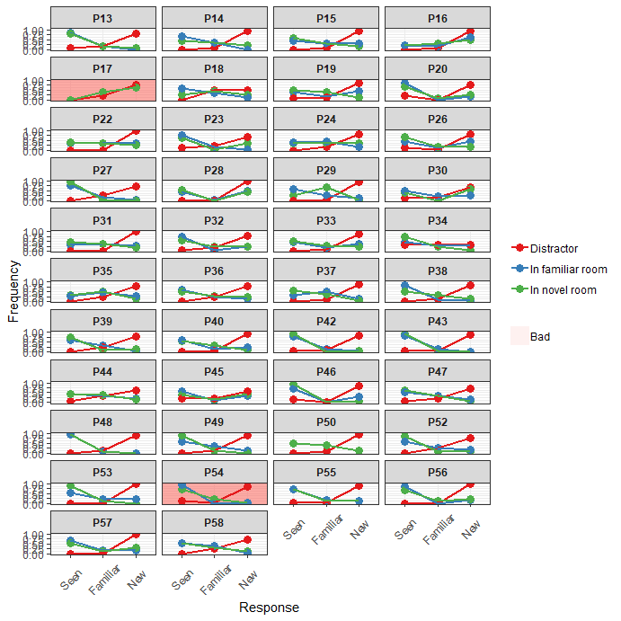

# 3 Novelty Benefits

## 3.1 Compare mean accuracy between *novel* and *familiar* rooms

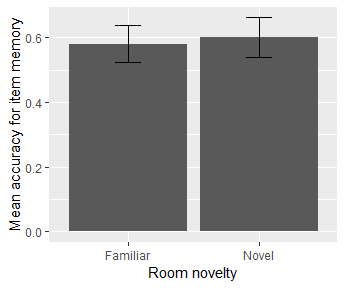

```
    Paired t-test

data:  MeanSeenHit by Group
t = -0.70766, df = 39, p-value = 0.4834
alternative hypothesis: true difference in means is not equal to 0
95 percent confidence interval:
 -0.07502193  0.03613304
sample estimates:
mean of the differences
            -0.01944444
```

## 3.2 Item memory as a function of item order

### 3.2.1 Visualise the data

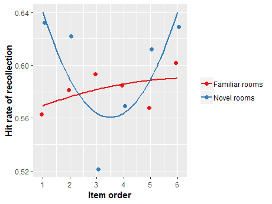

### 3.2.2 Testing novelty effects by fitting mixed models

Build models with item memory accuracy as $y$ and iexamine effects of item order and novelty by comparing the models.

#### 3.2.2.1 Parameter estimation for the complete model

```
Linear mixed-effects model fit by maximum likelihood
 Data: Encoding.Recall.Old
```

|  | AIC | BIC | logLik |
| --- | --- | --- | --- |
|  | 2012.872 | 2113.581 | -987.4358 |

```
Random effects:
 Formula: ~1 + ItemOrder + I(ItemOrder^2) | SubjectNo
 Structure: General positive-definite, Log-Cholesky parametrization
               StdDev       Corr
(Intercept)    1.889803e-01 (Intr) ItmOrd
ItemOrder      2.959981e-02 -0.43
I(ItemOrder^2) 1.585874e-06  0.00   0.00

 Formula: ~1 + ItemOrder + I(ItemOrder^2) | Group %in% SubjectNo
 Structure: General positive-definite, Log-Cholesky parametrization
               StdDev       Corr
(Intercept)    5.563326e-02 (Intr) ItmOrd
ItemOrder      1.711796e-03 -0.099
I(ItemOrder^2) 1.010701e-05 -0.002 -0.003
Residual       4.553860e-01

Fixed effects: SeenHit ~ ItemOrder + I(ItemOrder^2) + Group + ItemOrder:Group +      I(ItemOrder^2):Group
```

|  | Value | Std.Error | DF | t-value | p-value |
| --- | --- | --- | --- | --- | --- |
| (Intercept) | 0.5586427 | 0.07921518 | 1393 | 7.052218 | 0.0000 |
| ItemOrder | 0.0057826 | 0.04809866 | 1393 | 0.120223 | 0.9043 |
| I(ItemOrder^2) | -0.0001939 | 0.00669942 | 1393 | -0.028947 | 0.9769 |
| GroupNovel | 0.1355078 | 0.10450529 | 41 | 1.296660 | 0.2020 |
| ItemOrder:GroupNovel | -0.0875043 | 0.06796859 | 1393 | -1.287422 | 0.1982 |
| I(ItemOrder^2):GroupNovel | 0.0119172 | 0.00950883 | 1393 | 1.253272 | 0.2103 |

```
 Correlation:
                          (Intr) ItmOrd I(ItO^2) GrpNvl ItO:GN
ItemOrder                 -0.871
I(ItemOrder^2)             0.788 -0.974
GroupNovel                -0.655  0.649 -0.597
ItemOrder:GroupNovel       0.605 -0.701  0.690   -0.925
I(ItemOrder^2):GroupNovel -0.555  0.687 -0.705    0.848 -0.979

Standardized Within-Group Residuals:
       Min         Q1        Med         Q3        Max
-1.9296436 -1.0288719  0.4093838  0.8630574  1.6404237

Number of Observations: 1481
Number of Groups:
           SubjectNo Group %in% SubjectNo
                  42                   84
```

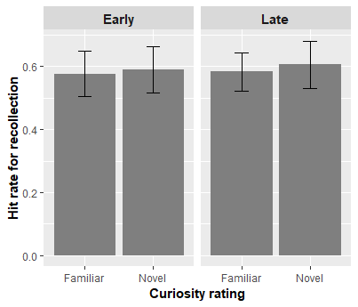

#### 3.2.3.1 Stats on it

```
Linear mixed-effects model fit by maximum likelihood
 Data: Encoding.Recall.Old.Collapsed.Grp[!SubjectNo %in% bad.ps.less.strict]
```

|  | AIC | BIC | logLik |
| --- | --- | --- | --- |
|  | -56.52645 | -31.92506 | 36.26323 |

```
Random effects:
 Formula: ~1 | SubjectNo
        (Intercept)
StdDev:   0.1463286

 Formula: ~1 | Group %in% SubjectNo
        (Intercept)
StdDev:  0.05295808

 Formula: ~1 | ItemOrderType %in% Group %in% SubjectNo
        (Intercept)   Residual
StdDev:   0.1460067 0.04983938

Fixed effects: SeenHit ~ Group * ItemOrderType
```

|  | Value | Std.Error | DF | t-value | p-value |
| --- | --- | --- | --- | --- | --- |
| (Intercept) | 0.5763889 | 0.03508910 | 78 | 16.426436 | 0.0000 |
| GroupNovel | 0.0136806 | 0.03693826 | 39 | 0.370363 | 0.7131 |
| ItemOrderTypeLate | 0.0069444 | 0.03493725 | 78 | 0.198769 | 0.8430 |
| GroupNovel:ItemOrderTypeLate | 0.0092857 | 0.04940874 | 78 | 0.187937 | 0.8514 |

```
 Correlation:
                             (Intr) GrpNvl ItmOTL
GroupNovel                   -0.526
ItemOrderTypeLate            -0.498  0.473
GroupNovel:ItemOrderTypeLate  0.352 -0.669 -0.707

Standardized Within-Group Residuals:
        Min          Q1         Med          Q3         Max
-0.66748931 -0.21538989  0.01036038  0.21194951  0.68784529

Number of Observations: 160
Number of Groups:
                              SubjectNo                    Group %in% SubjectNo
                                     40                                      80
ItemOrderType %in% Group %in% SubjectNo
                                    160
```

# 4 Curiosity Benefits

We hypothesed that the higher the curiosity rating was, the better the item memory should be.

## 4.1 Mean accuracy of item memory as a function of curiosity rating

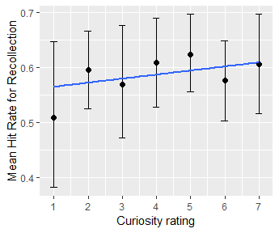

### 4.1.1 Testing the relationship between mean accuracy of item memory and curiosity rating

Build models with item memory accuracy as $y$ and examine effects of curiosity rating by including it into the model and then comparing the model fits.

- `baseline.rating` is the model with only an intercept, showing no change in item memory as a function of curiosity rating.
- `rating.intercept` is the model with $\small CuriosityRating$ included, showing the effects of curiosity rating.
- `rating.slope` is the model allowing the slope (i.e., relationship between item memory and curiosity rating) varying across participants.

|  | Model | df | AIC | BIC | logLik | Test | L.Ratio | p-value |
| --- | --- | --- | --- | --- | --- | --- | --- | --- |
| baseline.rating | 1 | 3 | -17.77382 | -7.382326 | 11.88691 |  |  |  |
| rating.intercept | 2 | 4 | -16.64659 | -2.791258 | 12.32329 | 1 vs 2 | 0.8727637 | 0.3502 |
| rating.slope | 3 | 6 | -14.01859 | 6.764396 | 13.00930 | 2 vs 3 | 1.3720095 | 0.5036 |

Including $\small CuriosityRating$ did not improve the model fit significantly, so may not play an important role.

#### 4.1.1.1 Parameter estimates in the complete model

```r
summary(rating.slope)
```

```
Linear mixed-effects model fit by maximum likelihood
 Data: InsideObjectsMemory
```

|  | AIC | BIC | logLik |
| --- | --- | --- | --- |
|  | -9.398555 | 11.68202 | 10.69928 |

```
Random effects:
 Formula: ~1 + CuriosityRating | SubjectNo
 Structure: General positive-definite, Log-Cholesky parametrization
                StdDev     Corr
(Intercept)     0.16724163 (Intr)
CuriosityRating 0.01536711 -0.089
Residual        0.19877319

Fixed effects: SeenHit ~ CuriosityRating
```

|  | Value | Std.Error | DF | t-value | p-value |
| --- | --- | --- | --- | --- | --- |
| (Intercept) | 0.5632424 | 0.04279706 | 205 | 13.160775 | 0.0000 |
| CuriosityRating | 0.0042536 | 0.00753174 | 205 | 0.564761 | 0.5729 |

```
 Correlation:
                (Intr)
CuriosityRating -0.717

Standardized Within-Group Residuals:
        Min          Q1         Med          Q3         Max
-2.42196730 -0.62225367  0.01444805  0.60994249  2.36657118

Number of Observations: 248
Number of Groups: 42
```

## 4.2 Does the relationship with curiosity rating depend on item order?

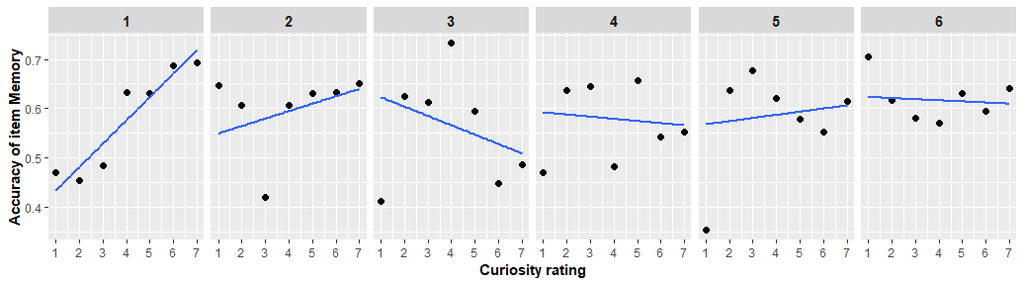

### 4.2.1 Testing the effect of item order

Build models with context memory accuracy as $y$ and examine effects of curiosity rating and item order by comparing the models.

- `item.model.linear.1` is the model with $\small ItemOrder$ included (in addition to $\small CuriosityRating$), showing the effects of item order.
- `item.model.linear.2` is the model allowing the slope (i.e., relationship between item memory and item order) varying across participants.
- `item.model.linear.3` is the model with the interaction between $\small ItemOrders$ and $\small CuriosityRating$ included.
- `item.model.quad.1` and `item.model.quad.2` repectively included $\small ItemOrder^2$ and related random effects.
- `item.model.quad.3` included interaction between $\small ItemOrder^2$ and $\small CuriosityRating$ for inestigating whether the pattern changes as a function of *curiosity rating*.

```r
rating.intercept <- update(baseline.item, .~. + CuriosityRating)
rating.slope     <- update(rating.intercept, random = ~ 1 + CuriosityRating | SubjectNo)
item.model.linear.1     <- update(rating.slope, .~. + ItemOrder)
item.model.linear.2     <- update(item.model.linear.1, random = list(~1+CuriosityRating+ItemOrder|SubjectNo))
item.model.linear.3     <- update(item.model.linear.2, .~. + ItemOrder : CuriosityRating)
item.model.quad.1       <- update(item.model.linear.3, .~. + I(ItemOrder^2))
# item.model.quad.2       <- update(item.model.quad.1,   random = list(~1+CuriosityRating|SubjectNo, ~1+ItemOrder+I(ItemOrder^2)|SubjectNo)) - excluding this model because singularity issue (perhaps the model was getting too complex to be calculated)
item.model.quad.3       <- update(item.model.quad.1,   .~. + I(ItemOrder^2) : CuriosityRating)
anova(rating.intercept, rating.slope, item.model.linear.1, item.model.linear.2, item.model.linear.3, item.model.quad.1, item.model.quad.3)
```

|  | Model | df | AIC | BIC | logLik | Test | L.Ratio | p-value |
| --- | --- | --- | --- | --- | --- | --- | --- | --- |
| rating.intercept | 1 | 5 | 1991.070 | 2017.572 | -990.5349 |  |  |  |
| rating.slope | 2 | 6 | 1992.558 | 2024.361 | -990.2792 | 1 vs 2 | 0.511376 | 0.4745 |
| item.model.linear.1 | 3 | 7 | 1994.456 | 2031.559 | -990.2278 | 2 vs 3 | 0.102752 | 0.7486 |
| item.model.linear.2 | 4 | 10 | 1996.958 | 2049.963 | -988.4790 | 3 vs 4 | 3.497612 | 0.3211 |
| item.model.linear.3 | 5 | 11 | 1996.684 | 2054.989 | -987.3421 | 4 vs 5 | 2.273853 | 0.1316 |
| item.model.quad.1 | 6 | 12 | 1997.236 | 2060.841 | -986.6178 | 5 vs 6 | 1.448523 | 0.2288 |
| item.model.quad.3 | 7 | 13 | 1995.108 | 2064.014 | -984.5540 | 6 vs 7 | 4.127638 | 0.0422 |

Including none of the predictors improved the model fit significantly except the last one.

#### 4.2.1.1 Parameter estimation for the complete model

```r
summary(item.model.quad.3)
```

```
Linear mixed-effects model fit by maximum likelihood
 Data: Encoding.Recall.Old
```

|  | AIC | BIC | logLik |
| --- | --- | --- | --- |
|  | 1995.108 | 2064.014 | -984.554 |

```
Random effects:
 Formula: ~1 + CuriosityRating + ItemOrder | SubjectNo
 Structure: General positive-definite, Log-Cholesky parametrization
                StdDev     Corr
(Intercept)     0.21536905 (Intr) CrstyR
CuriosityRating 0.02336181 -0.493
ItemOrder       0.02726838 -0.489  0.366
Residual        0.45469589

Fixed effects: SeenHit ~ CuriosityRating + ItemOrder + I(ItemOrder^2) + CuriosityRating:ItemOrder +      CuriosityRating:I(ItemOrder^2)
```

|  | Value | Std.Error | DF | t-value | p-value |
| --- | --- | --- | --- | --- | --- |
| (Intercept) | 0.31373646 | 0.13717807 | 1434 | 2.287074 | 0.0223 |
| CuriosityRating | 0.07108946 | 0.02795677 | 1434 | 2.542836 | 0.0111 |
| ItemOrder | 0.14552455 | 0.08664131 | 1434 | 1.679621 | 0.0932 |
| I(ItemOrder^2) | -0.01685196 | 0.01209142 | 1434 | -1.393712 | 0.1636 |
| CuriosityRating:ItemOrder | -0.04144945 | 0.01802151 | 1434 | -2.299998 | 0.0216 |
| CuriosityRating:I(ItemOrder^2) | 0.00510836 | 0.00251784 | 1434 | 2.028863 | 0.0427 |

```
 Correlation:
                               (Intr) CrstyR ItmOrd I(IO^2 CrR:IO
CuriosityRating                -0.901
ItemOrder                      -0.904  0.847
I(ItemOrder^2)                  0.823 -0.773 -0.977
CuriosityRating:ItemOrder       0.828 -0.919 -0.919  0.900
CuriosityRating:I(ItemOrder^2) -0.757  0.841  0.899 -0.920 -0.978

Standardized Within-Group Residuals:
       Min         Q1        Med         Q3        Max
-1.9037040 -1.0280561  0.4076989  0.8642786  1.6947228

Number of Observations: 1481
Number of Groups: 42
```

Interestingly, there is a significant interaction between Curiosity and item order.

#### 4.2.1.2 Was the relationship significantly positive for the first object?

```r
baseline.item.first <- lme(SeenHit ~ 1, random = ~ 1|SubjectNo/Group, data = Encoding.Recall.Old[!SubjectNo %in% bad.ps.less.strict & ItemOrder == 1], method = "ML", control = list(msMaxIter = 500, opt = "optim", msVerbose=FALSE), na.action = na.exclude)
rating.intercept.first <- update(baseline.item.first, .~. + CuriosityRating)
rating.slope.first     <- update(rating.intercept.first, random = ~ 1 + CuriosityRating|SubjectNo/Group)
anova(baseline.item.first, rating.intercept.first, rating.slope.first)
```

|  | Model | df | AIC | BIC | logLik | Test | L.Ratio | p-value |
| --- | --- | --- | --- | --- | --- | --- | --- | --- |
| baseline.item.first | 1 | 4 | 337.2541 | 351.1094 | -164.6270 |  |  |  |
| rating.intercept.first | 2 | 5 | 331.9718 | 349.2910 | -160.9859 | 1 vs 2 | 7.282266 | 0.007 |
| rating.slope.first | 3 | 9 | 339.9737 | 371.1482 | -160.9869 | 2 vs 3 | 0.001903 | 1.000 |

```r
summary(rating.intercept.first)
```

```
Linear mixed-effects model fit by maximum likelihood
 Data: Encoding.Recall.Old[!SubjectNo %in% bad.ps.less.strict & ItemOrder ==      1]
```

[output not shown]

[output not shown]

|  | Value | Std.Error | DF | t-value | p-value |
| --- | --- | --- | --- | --- | --- |
| (Intercept) | 0.3943964 | 0.08102909 | 195 | 4.867343 | 0.0000 |
| CuriosityRating | 0.0457090 | 0.01632029 | 195 | 2.800750 | 0.0056 |

```
 Correlation:
                (Intr)
CuriosityRating -0.893

Standardized Within-Group Residuals:
       Min         Q1        Med         Q3        Max
-1.6640263 -1.0769425  0.5600874  0.7881793  1.3289902

Number of Observations: 236
Number of Groups: 40
```

### 4.2.2 Collapse the order and curiosity rating

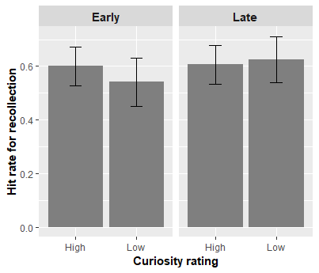

### 4.2.3 Try another way to calculate “High” and “Low” curiosity groups

> “High” - higher than mean; “Low” - lower than mean

#### 4.2.3.1 Compare “High” and “Low” groups

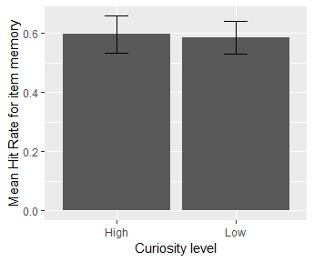

```
    Paired t-test

data:  SeenHit by RatingGroup
t = 0.43194, df = 39, p-value = 0.6682
alternative hypothesis: true difference in means is not equal to 0
95 percent confidence interval:
 -0.04654597  0.07182375
sample estimates:
mean of the differences
             0.01263889
```

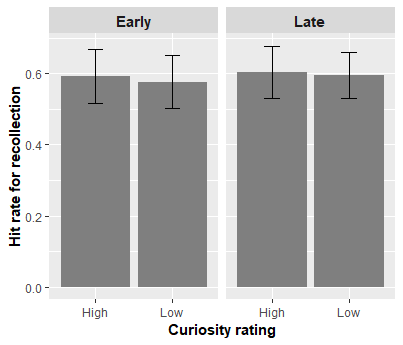

#### 4.2.3.2 Stats on it

```
Linear mixed-effects model fit by maximum likelihood
 Data: Encoding.Recall.Old.Collapsed.Alt[!SubjectNo %in% bad.ps.less.strict]
```

|  | AIC | BIC | logLik |
| --- | --- | --- | --- |
|  | -53.05813 | -28.45674 | 34.52906 |

```
Random effects:
 Formula: ~1 | SubjectNo
        (Intercept)
StdDev:   0.1461046

 Formula: ~1 | RatingGroup %in% SubjectNo
        (Intercept)
StdDev:  0.07228429

 Formula: ~1 | ItemOrderType %in% RatingGroup %in% SubjectNo
        (Intercept)  Residual
StdDev:   0.1416935 0.0536401

Fixed effects: SeenHit ~ RatingGroup * ItemOrderType
```

|  | Value | Std.Error | DF | t-value | p-value |
| --- | --- | --- | --- | --- | --- |
| (Intercept) | 0.5922159 | 0.03563558 | 78 | 16.618671 | 0.0000 |
| RatingGroupLow | -0.0158270 | 0.03801439 | 39 | -0.416343 | 0.6794 |
| ItemOrderTypeLate | 0.0114448 | 0.03430954 | 78 | 0.333575 | 0.7396 |
| RatingGroupLow:ItemOrderTypeLate | 0.0066108 | 0.04852101 | 78 | 0.136245 | 0.8920 |

```
 Correlation:
                                 (Intr) RtngGL ItmOTL
RatingGroupLow                   -0.533
ItemOrderTypeLate                -0.481  0.451
RatingGroupLow:ItemOrderTypeLate  0.340 -0.638 -0.707

Standardized Within-Group Residuals:
        Min          Q1         Med          Q3         Max
-0.72348786 -0.22425297  0.02856351  0.22242578  0.63031801

Number of Observations: 160
Number of Groups:
                                    SubjectNo                    RatingGroup %in% SubjectNo
                                           40                                            80
ItemOrderType %in% RatingGroup %in% SubjectNo
                                          160
```

# 5 Curiosity and novelty

## 5.1 Testing the effects of curiosity rating and novelty together

Build models with item memory accuracy as $y$ and examine effects of curiosity rating and novelty together by including them into the model separately and then comparing the model fits.

|  | Model | df | AIC | BIC | logLik | Test | L.Ratio | p-value |
| --- | --- | --- | --- | --- | --- | --- | --- | --- |
| baseline.rating | 1 | 4 | -15.849513 | -1.99419 | 11.92476 |  |  |  |
| rating.intercept | 2 | 5 | -14.648768 | 2.67039 | 12.32438 | 1 vs 2 | 0.7992554 | 0.3713 |
| rating.slope | 3 | 9 | -8.086345 | 23.08814 | 13.04317 | 2 vs 3 | 1.4375772 | 0.8376 |
| novelty.model | 4 | 10 | -6.145082 | 28.49324 | 13.07254 | 3 vs 4 | 0.0587373 | 0.8085 |
| interaction.model | 5 | 11 | -5.188978 | 32.91317 | 13.59449 | 4 vs 5 | 1.0438954 | 0.3069 |

### 5.1.1 Check the complete model

```
Linear mixed-effects model fit by maximum likelihood
 Data: InsideObjectsMemory[!SubjectNo %in% bad.ps.less.strict]
```

|  | AIC | BIC | logLik |
| --- | --- | --- | --- |
|  | -5.188978 | 32.91317 | 13.59449 |

```
Random effects:
 Formula: ~1 + CuriosityRating | SubjectNo
 Structure: General positive-definite, Log-Cholesky parametrization
                StdDev     Corr
(Intercept)     0.10174400 (Intr)
CuriosityRating 0.01170984 0.8

 Formula: ~1 + CuriosityRating | Group %in% SubjectNo
 Structure: General positive-definite, Log-Cholesky parametrization
                StdDev       Corr
(Intercept)     4.561404e-04 (Intr)
CuriosityRating 1.396199e-06 0
Residual        2.023225e-01

Fixed effects: SeenHit ~ CuriosityRating + Group + CuriosityRating:Group
```

|  | Value | Std.Error | DF | t-value | p-value |
| --- | --- | --- | --- | --- | --- |
| (Intercept) | 0.5280445 | 0.05002412 | 154 | 10.555798 | 0.0000 |
| CuriosityRating | 0.0179762 | 0.01479117 | 154 | 1.215333 | 0.2261 |
| GroupNovel | 0.1156603 | 0.13180907 | 39 | 0.877483 | 0.3856 |
| CuriosityRating:GroupNovel | -0.0256385 | 0.02512508 | 154 | -1.020437 | 0.3091 |

```
 Correlation:
                           (Intr) CrstyR GrpNvl
CuriosityRating            -0.828
GroupNovel                 -0.313  0.294
CuriosityRating:GroupNovel  0.482 -0.549 -0.941

Standardized Within-Group Residuals:
        Min          Q1         Med          Q3         Max
-2.29748748 -0.65632357 -0.02839334  0.66354935  2.26440403

Number of Observations: 236
Number of Groups:
           SubjectNo Group %in% SubjectNo
                  40                   80
```

## 5.2 What about the other way around

|  | Model | df | AIC | BIC | logLik | Test | L.Ratio | p-value |
| --- | --- | --- | --- | --- | --- | --- | --- | --- |
| baseline.rating | 1 | 4 | -15.849513 | -1.99419 | 11.92476 |  |  |  |
| novelty.model | 2 | 5 | -14.241189 | 3.07797 | 12.12059 | 1 vs 2 | 0.3916759 | 0.5314 |
| rating.model.1 | 3 | 6 | -12.681408 | 8.10158 | 12.34070 | 2 vs 3 | 0.4402198 | 0.5070 |
| rating.model.2 | 4 | 10 | -6.145082 | 28.49324 | 13.07254 | 3 vs 4 | 1.4636738 | 0.8331 |
| interaction.model | 5 | 11 | -5.188978 | 32.91317 | 13.59449 | 4 vs 5 | 1.0438957 | 0.3069 |

## 5.3 Check the collapsed data

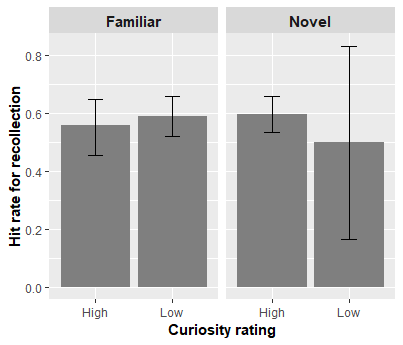

#### 5.3.0.1 Stats on it

```
Linear mixed-effects model fit by maximum likelihood
 Data: Encoding.Recall.Old.Collapsed.Interaction[!SubjectNo %in% bad.ps.less.strict]
```

|  | AIC | BIC | logLik |
| --- | --- | --- | --- |
|  | -26.45275 | -6.365875 | 21.22638 |

```
Random effects:
 Formula: ~1 | SubjectNo
        (Intercept)
StdDev:   0.1463208

 Formula: ~1 | CuriosityRatingType %in% SubjectNo
        (Intercept)
StdDev:   0.1016343

 Formula: ~1 | Group %in% CuriosityRatingType %in% SubjectNo
        (Intercept)   Residual
StdDev:    0.107718 0.04676211

Fixed effects: SeenHit ~ CuriosityRatingType * Group
```

|  | Value | Std.Error | DF | t-value | p-value |
| --- | --- | --- | --- | --- | --- |
| (Intercept) | 0.5888588 | 0.04909738 | 39 | 11.993692 | 0.0000 |
| CuriosityRatingTypeLow | 0.0004561 | 0.05153150 | 35 | 0.008851 | 0.9930 |
| GroupNovel | 0.0082940 | 0.04405888 | 13 | 0.188248 | 0.8536 |
| CuriosityRatingTypeLow:GroupNovel | -0.2171836 | 0.11727182 | 13 | -1.851967 | 0.0869 |

```
 Correlation:
                                  (Intr) CrsRTL GrpNvl
CuriosityRatingTypeLow            -0.746
GroupNovel                        -0.731  0.713
CuriosityRatingTypeLow:GroupNovel  0.284 -0.343 -0.386

Standardized Within-Group Residuals:
        Min          Q1         Med          Q3         Max
-0.59205382 -0.18915892 -0.02569644  0.19123451  0.69856187

Number of Observations: 91
Number of Groups:
                                    SubjectNo            CuriosityRatingType %in% SubjectNo
                                           40                                            76
Group %in% CuriosityRatingType %in% SubjectNo
                                           91
```

### 5.3.1 Alternative way to collapse data

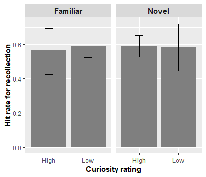

```
Linear mixed-effects model fit by maximum likelihood
 Data: Encoding.Recall.Old.Collapsed.Alt.Interaction[!SubjectNo %in%      bad.ps.less.strict]
```

|  | AIC | BIC | logLik |
| --- | --- | --- | --- |
|  | -40.81858 | -20.38756 | 28.40929 |

```
Random effects:
 Formula: ~1 | SubjectNo
        (Intercept)
StdDev:   0.1436154

 Formula: ~1 | RatingGroup %in% SubjectNo
        (Intercept)
StdDev:  0.04937842

 Formula: ~1 | Group %in% RatingGroup %in% SubjectNo
        (Intercept)   Residual
StdDev:    0.123806 0.03868137

Fixed effects: SeenHit ~ RatingGroup * Group
```

|  | Value | Std.Error | DF | t-value | p-value |
| --- | --- | --- | --- | --- | --- |
| (Intercept) | 0.5884270 | 0.05652563 | 39 | 10.409914 | 0.0000 |
| RatingGroupLow | 0.0018508 | 0.05621010 | 39 | 0.032926 | 0.9739 |
| GroupNovel | 0.0010869 | 0.05506637 | 13 | 0.019738 | 0.9846 |
| RatingGroupLow:GroupNovel | 0.0008304 | 0.09107219 | 13 | 0.009118 | 0.9929 |

```
 Correlation:
                          (Intr) RtngGL GrpNvl
RatingGroupLow            -0.836
GroupNovel                -0.833  0.838
RatingGroupLow:GroupNovel  0.591 -0.680 -0.694

Standardized Within-Group Residuals:
        Min          Q1         Med          Q3         Max
-0.46946182 -0.17317708 -0.02118408  0.15971733  0.69640847

Number of Observations: 95
Number of Groups:
                            SubjectNo            RatingGroup %in% SubjectNo
                                   40                                    80
Group %in% RatingGroup %in% SubjectNo
                                   95
```

# 6 Curiosity effects in the *Novel* group

## 6.1 Mean accuracy of item memory as a function of curiosity rating

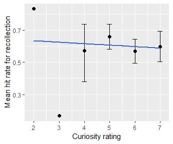